# Trabajo Práctico III AID-2022

Ejercicio 2. A un grupo de 350 adultos, quienes participaron en una encuesta, se les preguntó si accedían o no a Twiter. Las respuestas clasificadas por sexo fueron las siguientes:

```r
# Construimos la tabla
twit=rbind(c(14,25),c(159,152))
rownames(twit)<-c("Usa","No Usa")
colnames(twit)<-c("F","M")

#Visualizamos la tabla
twit%>%kable()%>%
  kable_paper("hover",
              full_width = F)
```

|  | F | M |
| --- | --- | --- |
| Usa | 14 | 25 |
| No Usa | 159 | 152 |

1. Represente gráficamente esta información. Interprete el gráfico.

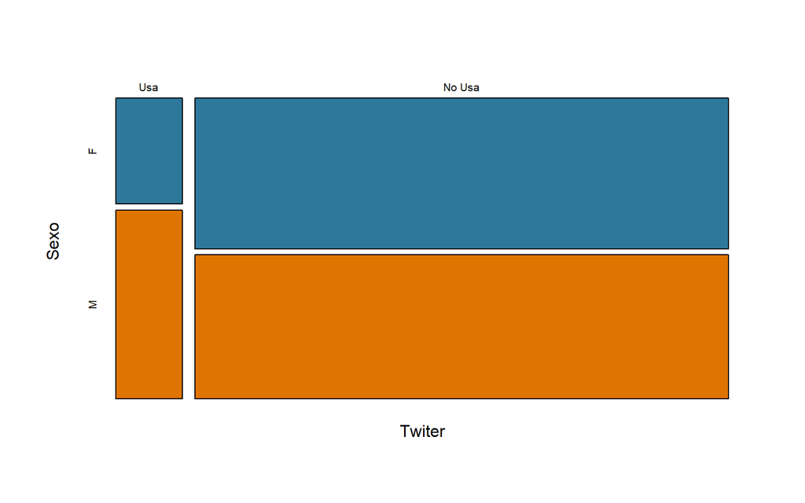

```r
twiter <- read_excel("C:/Users/Debora/Dropbox/Multiv_DM/Datos/twitter.xlsx")
mosaicplot(twit,main="",xlab="Twiter",ylab="Sexo",col=c("#2E789B","#DF7401"))
```

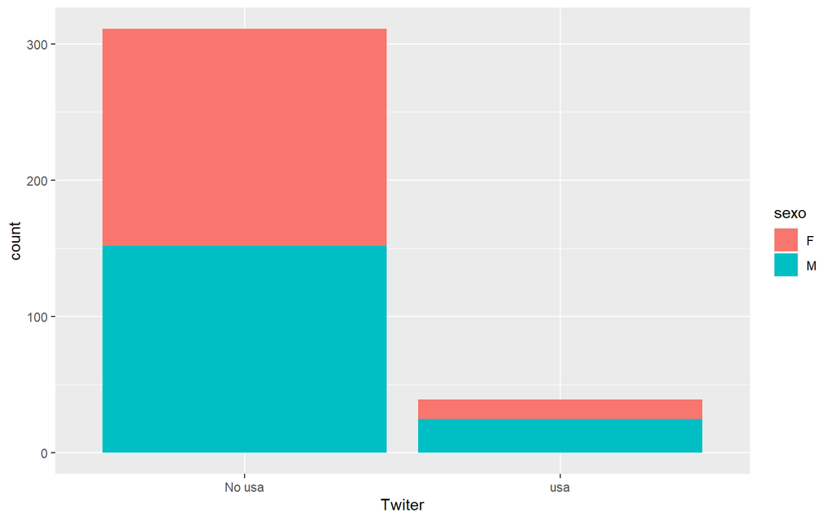

```r
sexo=as.factor(twiter$Sexo)
ggplot(twiter,aes(Twiter,fill=sexo))+geom_bar()
```

2. Obtenga los porcentajes por filas y compare las diferentes zonas.

```r
kable(round(prop.table(twit), 2))#proporciones totales reducidas a 2 decimales
```

|  | F | M |
| --- | --- | --- |
| Usa | 0.04 | 0.07 |
| No Usa | 0.45 | 0.43 |

```r
kable(round(prop.table(twit, 1), 2) )#proporciones por fila reducida a 2 decimales
```

|  | F | M |
| --- | --- | --- |
| Usa | 0.36 | 0.64 |
| No Usa | 0.51 | 0.49 |

```r
kable(round(prop.table(twit, 2), 2)) #proporciones por columna reducida a 2 decimales
```

|  | F | M |
| --- | --- | --- |
| Usa | 0.08 | 0.14 |
| No Usa | 0.92 | 0.86 |

```r
kable(addmargins(twit, c(1, 2))) #agrega los totales
```

|  | F | M | Sum |
| --- | --- | --- | --- |
| Usa | 14 | 25 | 39 |
| No Usa | 159 | 152 | 311 |
| Sum | 173 | 177 | 350 |

3. Obtenga los porcentajes por zona y compare las diferentes especialidades.

```r
tw_caba=dplyr::filter(twiter,Zona=='CABA')
tw_pba=dplyr::filter(twiter,Zona=='PBA')
tab_caba=tw_caba%>%dplyr::select(Twiter,Sexo)%>%table()
tab_pba=tw_pba%>%dplyr::select(Twiter,Sexo)%>%table()
kable(tab_caba)
```

|  | F | M |
| --- | --- | --- |
| No usa | 20 | 21 |
| usa | 6 | 6 |

```r
kable(tab_pba)
```

|  | F | M |
| --- | --- | --- |
| No usa | 139 | 131 |
| usa | 8 | 19 |

```r
kable(round(prop.table(tab_caba), 2))
```

|  | F | M |
| --- | --- | --- |
| No usa | 0.38 | 0.40 |
| usa | 0.11 | 0.11 |

```r
kable(round(prop.table(tab_pba), 2))
```

|  | F | M |
| --- | --- | --- |
| No usa | 0.47 | 0.44 |
| usa | 0.03 | 0.06 |

4. Calcule las frecuencias esperadas bajo independencia y compárelas con las observadas.

```r
sal_chi=chisq.test(twit)
sal_chi$expected%>%round(2)
```

```
##             F      M
## Usa     19.28  19.72
## No Usa 153.72 157.28
```

```r
twit
```

```
##          F   M
## Usa     14  25
## No Usa 159 152
```

5. ¿Sugieren estos datos que existe diferencia de proporciones entre mujeres y hombres que acceden o no a Twiter? Considerar $\alpha$ = 0, 05.

```r
sal_chi=chisq.test(twit)
sal_chi
```

```
##
##  Pearson's Chi-squared test with Yates' continuity correction
##
## data:  twit
## X-squared = 2.6345, df = 1, p-value = 0.1046
```

# Ejercicio 3

**Se clasificó en forma cruzada una muestra de 250 técnicos en telecomunicaciones en base a su especialidad y a la zona de la comunidad en que estaban trabajando. Los resultados están tabulados a continuacion:**

```r
mat=rbind(c(20,18,12,17),
      c(6,22,15,13),
      c(4,6,14,11),
      c(10,19,23,40))
colnames(mat)<-c("A","B","C","D")
rownames(mat)<-c("Norte", "Sur","Este","Oeste")
kable(addmargins(mat, c(1, 2)))
```

|  | A | B | C | D | Sum |
| --- | --- | --- | --- | --- | --- |
| Norte | 20 | 18 | 12 | 17 | 67 |
| Sur | 6 | 22 | 15 | 13 | 56 |
| Este | 4 | 6 | 14 | 11 | 35 |
| Oeste | 10 | 19 | 23 | 40 | 92 |
| Sum | 40 | 65 | 64 | 81 | 250 |

1. Considera adecuado un test de homogeneidad o de independencia? Fundamente su respuesta considerando el tipo de muestreo realizado.

**Miren el muestreo!!**

2. Establezca las hipótesis de interés, realice el contraste y concluya considerando un nivel de significación del 1 %.

$H_O:$ la especialidad es independiente de la zona

$H_1:$ la especialidad y la zona están asociadas

```r
prueba=chisq.test(mat)
pvalor=prueba$p.value
pvalor
```

```
## [1] 0.001261069
```

```r
residuos=prueba$residuals
residuos
```

```
##                A          B          C          D
## Norte  2.8343311  0.1389645 -1.2439945 -1.0104773
## Sur   -0.9888666  1.9498098  0.1753695 -1.2076315
## Este  -0.6761234 -1.0276400  1.6837458 -0.1009654
## Oeste -1.2302350 -1.0059688 -0.1137431  1.8667794
```

```r
observados=prueba$observed
observados
```

```
##        A  B  C  D
## Norte 20 18 12 17
## Sur    6 22 15 13
## Este   4  6 14 11
## Oeste 10 19 23 40
```

```r
esperados=prueba$expected
esperados
```

```
##           A     B      C      D
## Norte 10.72 17.42 17.152 21.708
## Sur    8.96 14.56 14.336 18.144
## Este   5.60  9.10  8.960 11.340
## Oeste 14.72 23.92 23.552 29.808
```

## ¿Se cumplen los supuestos de la prueba?

# Ejercicio 5.

**Se ha realizado una encuesta entre el personal de una empresa. Se le preguntó a cada uno el cargo que desempeña y la cantidad de cigarrillos diarios que fuma. La frecuencia de fumador fue categorizada con las categorías: No fuma- Fuma Poco – Fumador Medio y Fuma Mucho En la Tabla4 se resumen las respuestas.**

```r
dat_fum=rbind(Ger_Senior= c(4, 2, 3, 2) ,
Ger_Junior=c( 4, 3 ,7 ,4 ),
Empl_Senior=c( 25, 10, 12, 4) ,
Empl_Junior=c( 18 ,24 ,33, 13) ,
Secretarias= c(10 ,6, 7, 2 ))
colnames(dat_fum)<-c("No fuma", "Poco", "Medio", "Mucho")
dat_fum%>%kable()%>%
  kable_paper("hover",
              full_width = F)
```

|  | No fuma | Poco | Medio | Mucho |
| --- | --- | --- | --- | --- |
| Ger_Senior | 4 | 2 | 3 | 2 |
| Ger_Junior | 4 | 3 | 7 | 4 |
| Empl_Senior | 25 | 10 | 12 | 4 |
| Empl_Junior | 18 | 24 | 33 | 13 |
| Secretarias | 10 | 6 | 7 | 2 |

Estamos interesados en estudiar la relación, si existiera entre las variables:”puesto de trabajo” y “nivel de fumador” en el contexto de esta empresa.

1. La primer pregunta que nos hacemos es si la distribución de la variable fumador es similar en todos los niveles de la variable puesto de desempeño. Construya para eso las distribuciones condicionales de fumador a cada grupo de trabajo.

```r
kable(round(prop.table(dat_fum, 1), 2) ) # perfiles fila reducida a 2 decimales
```

|  | No fuma | Poco | Medio | Mucho |
| --- | --- | --- | --- | --- |
| Ger_Senior | 0.36 | 0.18 | 0.27 | 0.18 |
| Ger_Junior | 0.22 | 0.17 | 0.39 | 0.22 |
| Empl_Senior | 0.49 | 0.20 | 0.24 | 0.08 |
| Empl_Junior | 0.20 | 0.27 | 0.38 | 0.15 |
| Secretarias | 0.40 | 0.24 | 0.28 | 0.08 |

2. Realice un análisis de correspondencias para estos datos. ¿Cuántos factores tiene sentido considerar?

# Análisis de Correspondencias

```r
fum.ca <- CA(dat_fum, graph = FALSE)
summary(fum.ca, nb.dec = 2, ncp = 2)
```

```
##
## Call:
## CA(X = dat_fum, graph = FALSE)
##
## The chi square of independence between the two variables is equal to 16.44164 (p-value =  0.1718348 ).
##
## Eigenvalues
##                       Dim.1  Dim.2  Dim.3
## Variance               0.07   0.01   0.00
## % of var.             87.76  11.76   0.49
## Cumulative % of var.  87.76  99.51 100.00
##
## Rows
##               Iner*1000   Dim.1   ctr  cos2   Dim.2   ctr  cos2
## Ger_Senior  |      2.67 | -0.07  0.33  0.09 |  0.19 21.36  0.80 |
## Ger_Junior  |     11.88 |  0.26  8.37  0.53 |  0.24 55.12  0.46 |
## Empl_Senior |     38.31 | -0.38 51.20  1.00 |  0.01  0.30  0.00 |
## Empl_Junior |     26.27 |  0.23 33.10  0.94 | -0.06 15.18  0.06 |
## Secretarias |      6.05 | -0.20  7.01  0.87 | -0.08  8.05  0.13 |
##
## Columns
##               Iner*1000   Dim.1   ctr  cos2   Dim.2   ctr  cos2
## No fuma     |     49.19 | -0.39 65.40  0.99 |  0.03  2.93  0.01 |
## Poco        |      7.06 |  0.10  3.08  0.33 | -0.14 46.32  0.66 |
## Medio       |     12.61 |  0.20 16.56  0.98 | -0.01  0.17  0.00 |
## Mucho       |     16.33 |  0.29 14.95  0.68 |  0.20 50.58  0.31 |
```

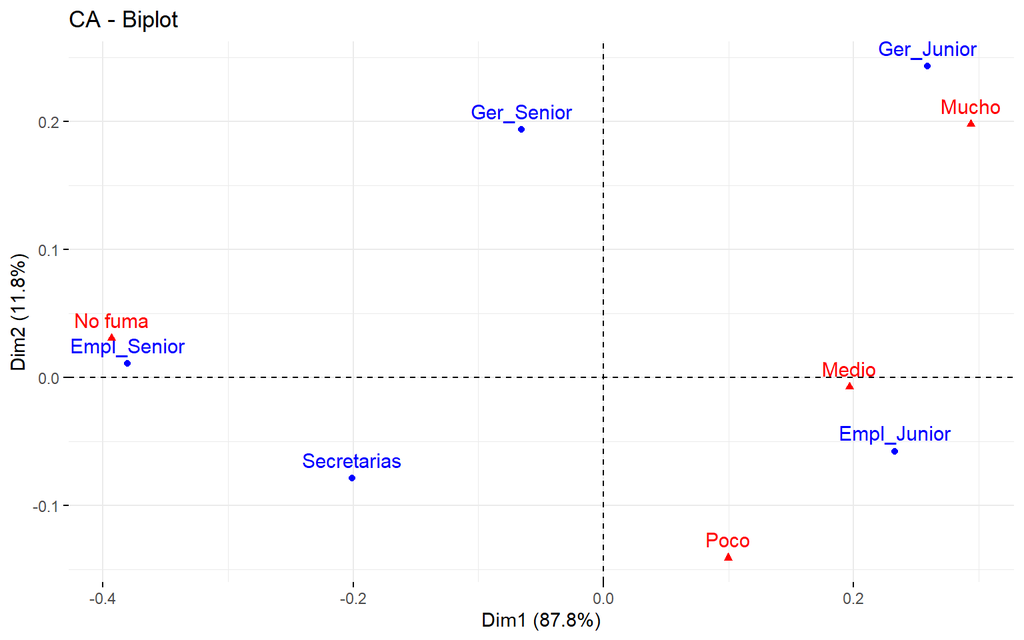

```r
fviz_ca_biplot(fum.ca) #mapa perceptual
```

3. Realizar los gráficos perfiles que considere adecuados.

# Perfiles Fila

```r
prop.table(dat_fum, 1)
```

```
##               No fuma      Poco     Medio      Mucho
## Ger_Senior  0.3636364 0.1818182 0.2727273 0.18181818
## Ger_Junior  0.2222222 0.1666667 0.3888889 0.22222222
## Empl_Senior 0.4901961 0.1960784 0.2352941 0.07843137
## Empl_Junior 0.2045455 0.2727273 0.3750000 0.14772727
## Secretarias 0.4000000 0.2400000 0.2800000 0.08000000
```

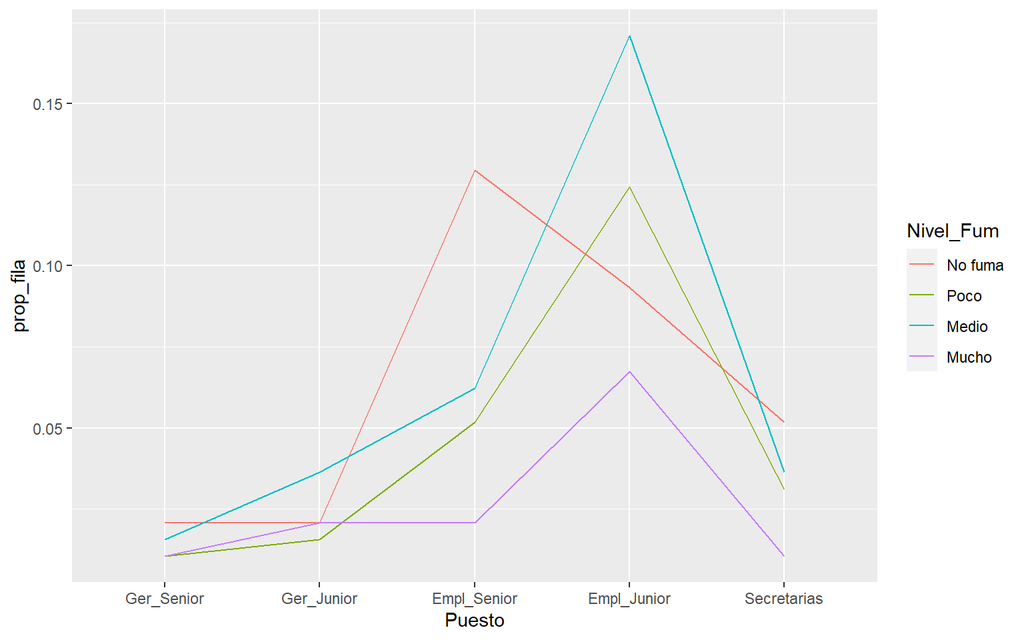

```r
datosf = melt(prop.table(dat_fum))
colnames(datosf)<-c("Puesto","Nivel_Fum","prop_fila")
ggplot(datosf,aes(x=Puesto,y=prop_fila,group=Nivel_Fum,col=Nivel_Fum))+geom_line()
```

# Perfiles Columna

```r
prop.table(dat_fum, 2)
```

```
##                No fuma       Poco     Medio Mucho
## Ger_Senior  0.06557377 0.04444444 0.0483871  0.08
## Ger_Junior  0.06557377 0.06666667 0.1129032  0.16
## Empl_Senior 0.40983607 0.22222222 0.1935484  0.16
## Empl_Junior 0.29508197 0.53333333 0.5322581  0.52
## Secretarias 0.16393443 0.13333333 0.1129032  0.08
```

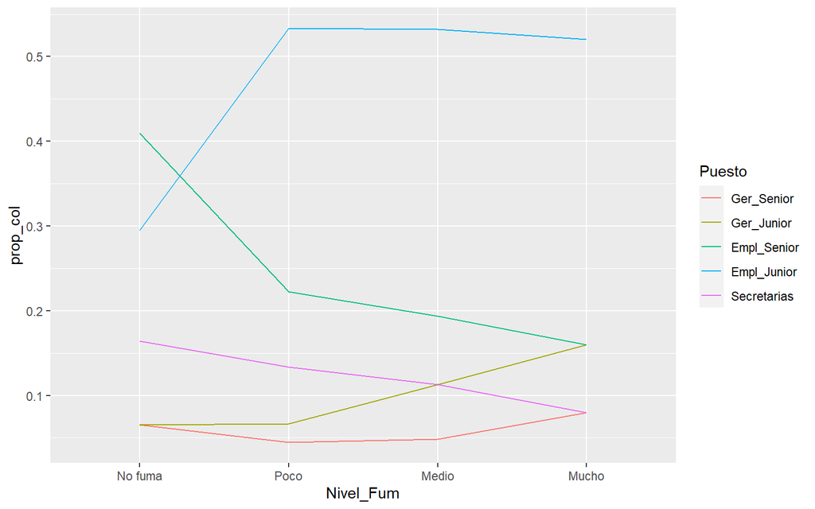

```r
datosc = melt(prop.table(dat_fum,2))
colnames(datosc)<-c("Puesto","Nivel_Fum","prop_col")
ggplot(datosc,aes(x=Nivel_Fum,y=prop_col,group=Puesto,col=Puesto))+geom_line()
```

4. Explique la calidad de la representación y las relaciones entre las variables y los ejes (inercia, calidad, cosenos).

```r
summary(fum.ca, nb.dec = 2, ncp = 2)
```

```
##
## Call:
## CA(X = dat_fum, graph = FALSE)
##
## The chi square of independence between the two variables is equal to 16.44164 (p-value =  0.1718348 ).
##
## Eigenvalues
##                       Dim.1  Dim.2  Dim.3
## Variance               0.07   0.01   0.00
## % of var.             87.76  11.76   0.49
## Cumulative % of var.  87.76  99.51 100.00
##
## Rows
##               Iner*1000   Dim.1   ctr  cos2   Dim.2   ctr  cos2
## Ger_Senior  |      2.67 | -0.07  0.33  0.09 |  0.19 21.36  0.80 |
## Ger_Junior  |     11.88 |  0.26  8.37  0.53 |  0.24 55.12  0.46 |
## Empl_Senior |     38.31 | -0.38 51.20  1.00 |  0.01  0.30  0.00 |
## Empl_Junior |     26.27 |  0.23 33.10  0.94 | -0.06 15.18  0.06 |
## Secretarias |      6.05 | -0.20  7.01  0.87 | -0.08  8.05  0.13 |
##
## Columns
##               Iner*1000   Dim.1   ctr  cos2   Dim.2   ctr  cos2
## No fuma     |     49.19 | -0.39 65.40  0.99 |  0.03  2.93  0.01 |
## Poco        |      7.06 |  0.10  3.08  0.33 | -0.14 46.32  0.66 |
## Medio       |     12.61 |  0.20 16.56  0.98 | -0.01  0.17  0.00 |
## Mucho       |     16.33 |  0.29 14.95  0.68 |  0.20 50.58  0.31 |
```

5. Hacer una síntesis de sus conclusiones, inspeccione relaciones entre perfiles fila, entre perfiles columna, asociaciones entre filas y columnas de manera adecuada.

#Resultados del análisis por Variable

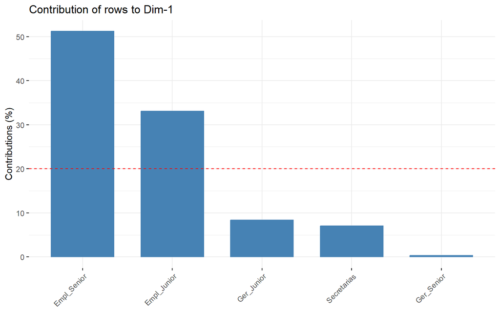

```r
fviz_contrib(fum.ca, choice = "row", axes = 1)#contribuciones por fila
```

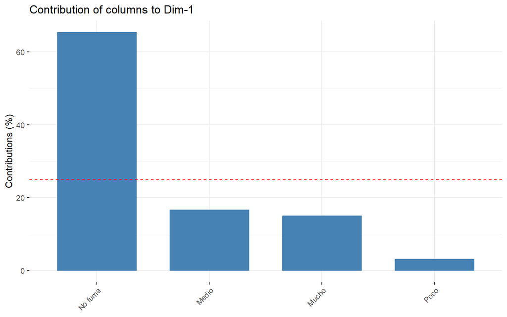

```r
fviz_contrib(fum.ca, choice = "col", axes = 1)#contribuciones por columna
```

6. ¿Cual es la inercia total?

```r
inercia=chisq.test(dat_fum)$statistic/193
inercia
```

```
##  X-squared
## 0.08518986
```